Import the race results (parsed from HTML via python’s BeautifulSoup), corral assignments, and the time windows associated with each corral.

```r
setwd("/Users/clmcleod/GitHub/sideProjects/Running/RunningData/PhillyMarathon2014/")
fullResults <- read.csv("Philly2014RaceResults-HTML/fullResults.csv")

corralAssignments <- read.csv("corralAssignments.csv")

predict <- read.csv("corralPredictions.csv")

predict[, 2:5] <- lapply(predict[,2:5],
                         function(x){as.POSIXct(strptime(x, '%H:%M:%S'))} )
```

Clean up the data. Two individuals have NA bib numbers due to legacy quaalification.

```r
#remove leading spaces
corralAssignments <- trim(corralAssignments)
corralAssignments$registration <- gsub("Half Marathon", "Half", corralAssignments$registration)

# remove 8k results, since we aren't interested in those
c<-subset(corralAssignments, registration %in% c("Half", "Marathon"))
```

Now, match the registrant and finisher data by merging across bib number. Make sure the demographic information matches across the two tables - it doesn’t always, and we’ll remove these results.

```r
#match up registration with results info by bib #
#the NAs introduced by coercion here are the 2 legacy runners
fullResults$match<-as.integer(fullResults$bib)
c$match<-as.numeric( levels(c$bib) )[c$bib]
m <- merge(fullResults, c, by.x = "match", by.y = "match", sort=TRUE)

#flag observation as suspicious if sex and age aren't consistent b/w data sources
m$flag <- ( m$sex.x == m$sex.y  &  abs(m$age.x-m$age.y)<2 )
suspicious <- m[!m$flag, ]

#clean is a data frame that contains both half and full marathon data, for finishers and non-finishers
#we've removed the legacy runners and the registrants who had inconsistent demographic information
clean<-m[m$flag, ]
```

Next, convert the HH:MM:SS times to just seconds for easier modeling later. These functions were taken directly from http://stackoverflow.com/questions/10835908/is-there-a-way-to-convert-mmss-00-to-seconds-00-in-r

```r
clean$netTime<- as.POSIXct(strptime(clean$net, '%H:%M:%S'))
clean$netSec <- toSeconds(as.character(clean$net))
```

Now, we’ll create a designation for registrants who didn’t finish (DNF). Now we have all the pieces necessary to create a graph showing finisher outcomes. We can also tabulate the data directly.

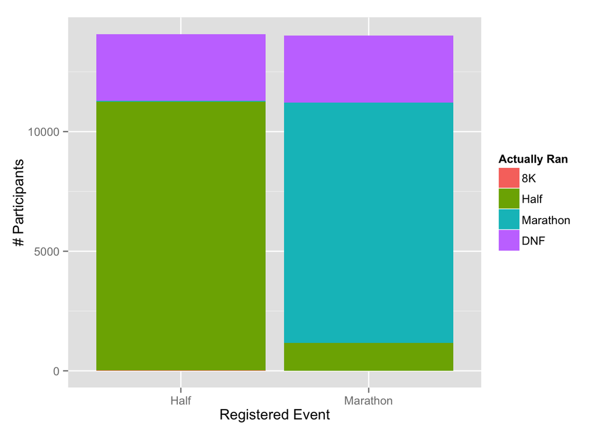

```r
# if a participant had a net time of "", change event to DNF
# (need to add DNF as a level first)
levels(clean$event) <- c(levels(clean$event), "DNF")
clean$event[clean$net == ""] = "DNF"
clean$DNF = ifelse(clean$net == "", 1, 0)

#bar plot of registration-finisher data
ggplot(clean)+
  geom_bar(aes(x=registration, stat="bin", fill=event))+
  ylab("# Participants")+
  xlab("Registered Event")+
  guides(fill=guide_legend(title="Actually Ran"))
```

```r
clean$reg.ran <- interaction(clean$registration, clean$event)
summary(clean$reg.ran)
```

```
##           Half.8K       Marathon.8K         Half.Half     Marathon.Half
##                28                 2             11228              1172
##     Half.Marathon Marathon.Marathon          Half.DNF      Marathon.DNF
##                25             10048              2795              2797
```

```r
#remove some duplicate fields from the dataset
drops <- c("bib.x", "sex.x", "age.x", "match", "flag")
clean <- clean[, !names(clean) %in% drops]
clean <- rename(clean, c("sex.y" = "sex", "age.y"="age", "bib.y"="bib"))
```

I think a much better visualization for this is a Sankey diagram. I used a great online tool called Sankeymatic - here’s the input for that.

```r
# http://sankeymatic.com/
#
# Marathon Registrants[10048] Marathon Finishers #8904B1
# Marathon Registrants[1172] Half Marathon Finishers #8904B1
# Marathon Registrants [2797] DNF #8904B1
# Marathon Registrants [2] 8k Finishers
#
# Half Marathon Registrants [11228] Half Marathon Finishers #04B431
# Half Marathon Registrants [2795] DNF #04B431
# Half Marathon Registrants [28] 8k Finishers #04B431
#
# 8k Registrants [1670] 8k Finishers #045FB4
# 8k Registrants [644] DNF #045FB4
#
# :DNF #848484
# :Half Marathon Finishers #04B431
# :Half Marathon Registrants #04B431
# :Marathon Finishers #8904B1
# :Marathon Registrants #8904B1
```

Finally, some quick linear modeling …

```r
#r.mar contains just data for marathon finishers
r.mar <- clean[ clean$reg.ran %in% c("Marathon.Marathon"), ]

summary(lm( netSec ~  sex * age, data = r.mar))
```

```
##
## Call:
## lm(formula = netSec ~ sex * age, data = r.mar)
##
## Residuals:
##     Min      1Q  Median      3Q     Max
## -9137.1 -2097.2  -374.6  1709.0 17705.1
##
## Coefficients:
##              Estimate Std. Error t value Pr(>|t|)
## (Intercept) 14770.484    156.805  94.196  < 2e-16 ***
## sexM        -1534.058    208.590  -7.354 2.07e-13 ***
## age            46.716      4.256  10.977  < 2e-16 ***
## sexM:age       -4.982      5.452  -0.914    0.361
## ---
## Signif. codes:  0 '***' 0.001 '**' 0.01 '*' 0.05 '.' 0.1 ' ' 1
##
## Residual standard error: 2806 on 10044 degrees of freedom
## Multiple R-squared:  0.0946, Adjusted R-squared:  0.09432
## F-statistic: 349.8 on 3 and 10044 DF,  p-value: < 2.2e-16
```

```r
summary(lm( netSec ~  corral, data = r.mar))
```

```
##
## Call:
## lm(formula = netSec ~ corral, data = r.mar)
##
## Residuals:
##     Min      1Q  Median      3Q     Max
## -8467.2 -1150.8  -311.1   836.0 14069.8
##
## Coefficients:
##                  Estimate Std. Error t value Pr(>|t|)
## (Intercept)       10493.6      351.1  29.891  < 2e-16 ***
## corral0 - Wheel     199.0      693.3   0.287    0.774
## corral1 - Maroon   1490.5      355.5   4.192 2.78e-05 ***
## corral2 - Black    2886.3      354.5   8.143 4.32e-16 ***
## corral3 - Green    4108.9      353.8  11.614  < 2e-16 ***
## corral4 - Gray     5132.6      354.7  14.470  < 2e-16 ***
## corral5 - Purple   5633.2      357.0  15.780  < 2e-16 ***
## corral6 - Orange   6839.0      353.5  19.344  < 2e-16 ***
## corral7 - Blue     9132.7      355.1  25.716  < 2e-16 ***
## ---
## Signif. codes:  0 '***' 0.001 '**' 0.01 '*' 0.05 '.' 0.1 ' ' 1
##
## Residual standard error: 1891 on 10039 degrees of freedom
## Multiple R-squared:  0.5891, Adjusted R-squared:  0.5888
## F-statistic:  1799 on 8 and 10039 DF,  p-value: < 2.2e-16
```

```r
# does demographic information predict who finishes?
marathon.registrants <- clean[ clean$registration %in% c("Marathon"),]
summary(glm(DNF ~ sex * age, family = "binomial", data = marathon.registrants))
```

```
##
## Call:
## glm(formula = DNF ~ sex * age, family = "binomial", data = marathon.registrants)
##
## Deviance Residuals:
##     Min       1Q   Median       3Q      Max
## -0.8177  -0.6691  -0.6639  -0.6265   1.9034
##
## Coefficients:
##               Estimate Std. Error z value Pr(>|z|)
## (Intercept) -1.4238436  0.1176256 -12.105   <2e-16 ***
## sexM        -0.3759589  0.1584475  -2.373   0.0177 *
## age          0.0008778  0.0031846   0.276   0.7828
## sexM:age     0.0095509  0.0040836   2.339   0.0193 *
## ---
## Signif. codes:  0 '***' 0.001 '**' 0.01 '*' 0.05 '.' 0.1 ' ' 1
##
## (Dispersion parameter for binomial family taken to be 1)
##
##     Null deviance: 14011  on 14018  degrees of freedom
## Residual deviance: 13995  on 14015  degrees of freedom
## AIC: 14003
##
## Number of Fisher Scoring iterations: 4
```

… and some graphs of marathon finish time as a function of age and gender:

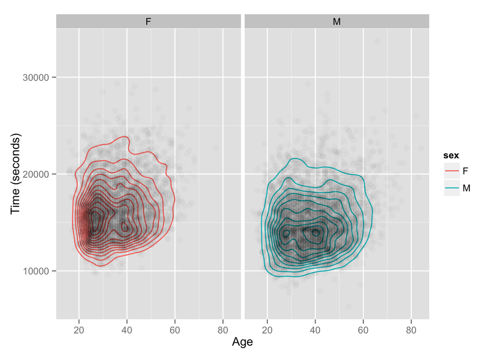

```r
ggplot(r.mar)+
  geom_density2d(aes(x=age, y= netSec, color=sex) ) +
  geom_point(aes(x=age, y=netSec), alpha = 0.02, size = 3) +
  facet_grid(.~sex)+
  ylab("Time (seconds)")+
  xlab("Age")
```

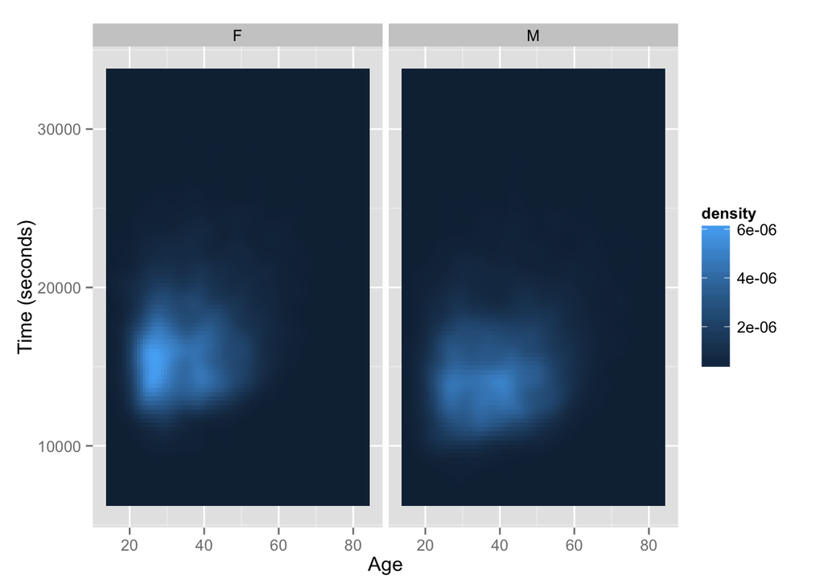

```r
ggplot(data = r.mar, aes(x=age, y= netSec)) +
  stat_density2d(geom="tile", aes(fill = ..density..), contour = FALSE)+
  facet_grid(.~sex)+
  ylab("Time (seconds)")+
  xlab("Age")
```